# proj climate model outputs

## compare model output with data

not sure if these plots are necessary, can describe the process and results

but if keeping, should include number of parameter sets for each tree sp

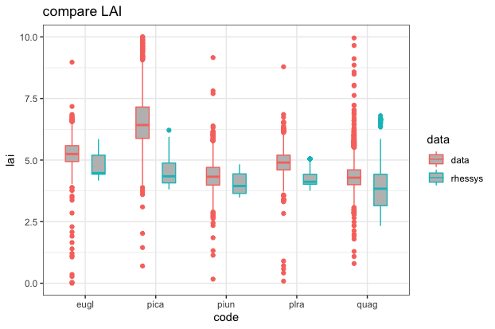

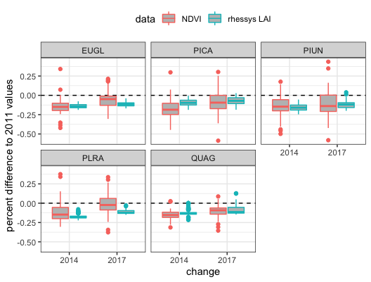

main rhessys outputs:

- bd gpsn Gross Photosynthesis gC/m2
- bd resp _ Respiration gC/m2
- npp = gpsn - resp
- LAI
- transpiration

## Resistance and resilience to drought

ratio to pre-drought LAI and NPP in 2011 during and after (2017) drought

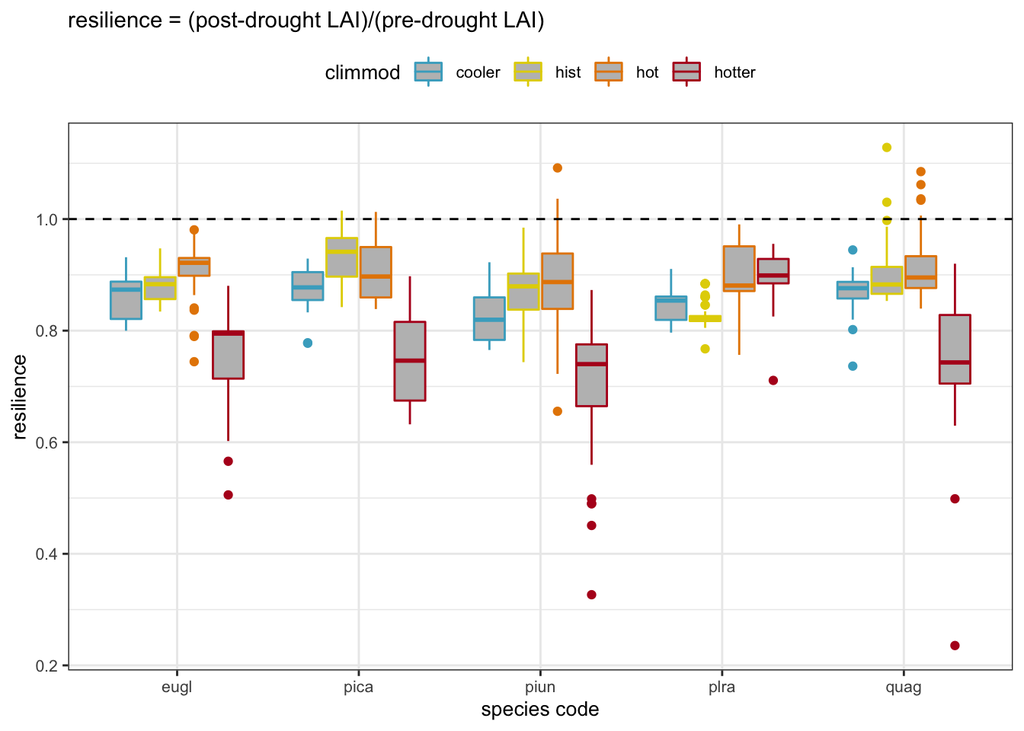

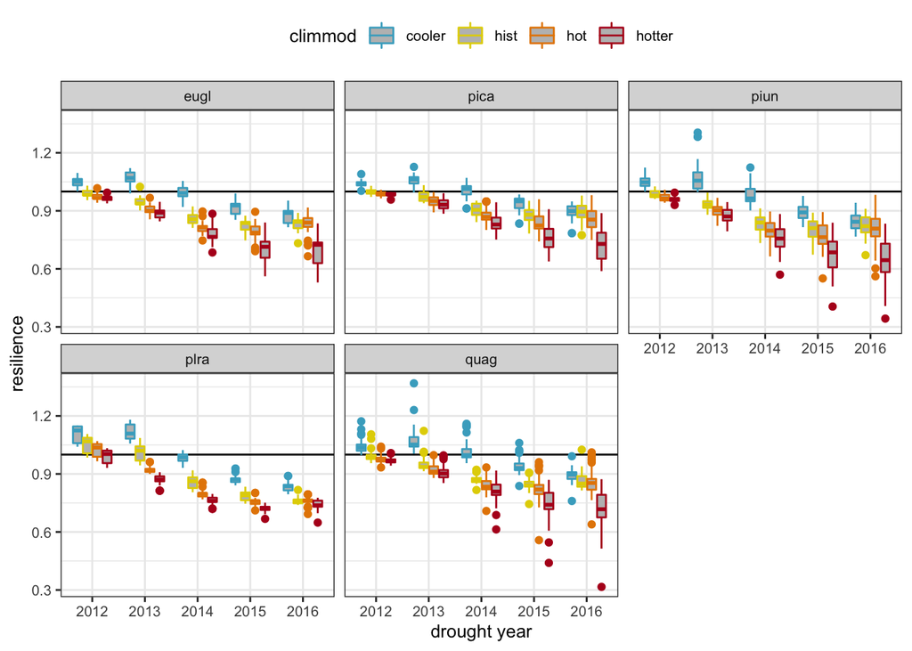

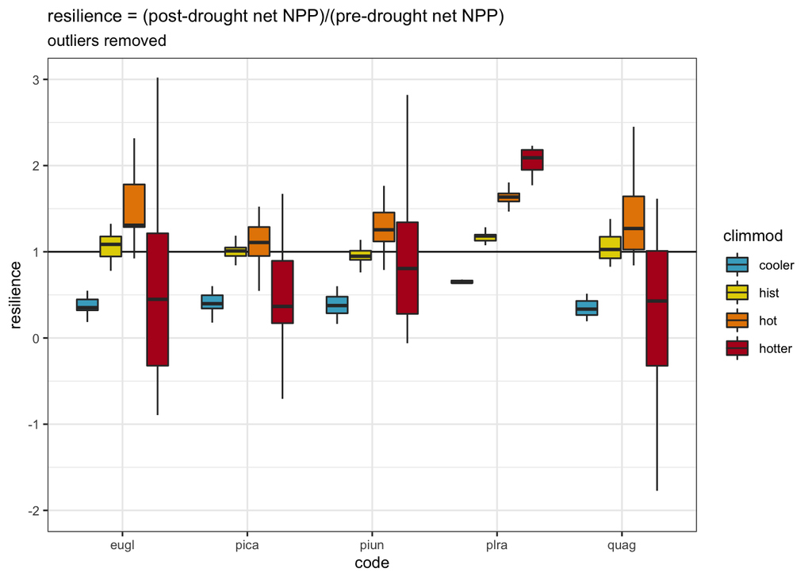

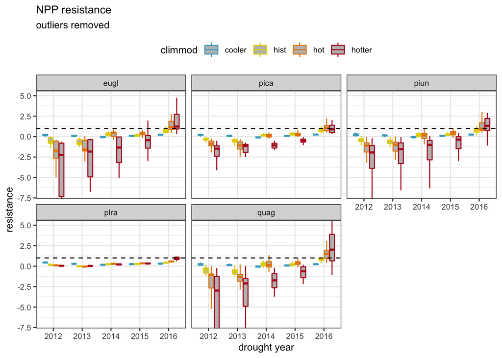

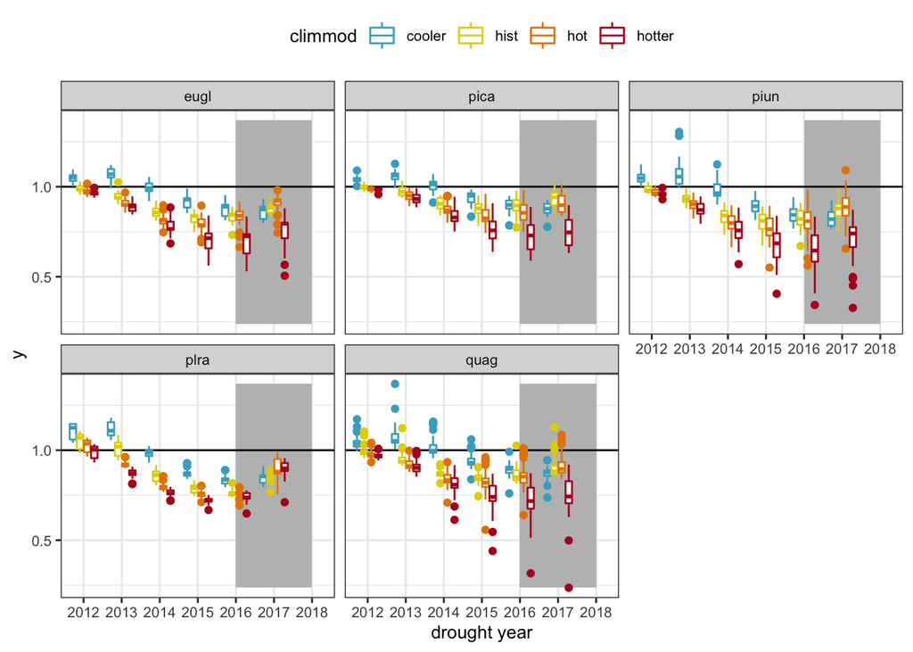

above plot includes resistance years 2012-2016 and resilience in 2017, which is meant to be shaded to differentiate. Both are ratios of the 2011 LAI. Wasn’t quite able to get the shading right but the idea is there I think.

## Annual and seasonal changes in carbon fluxes

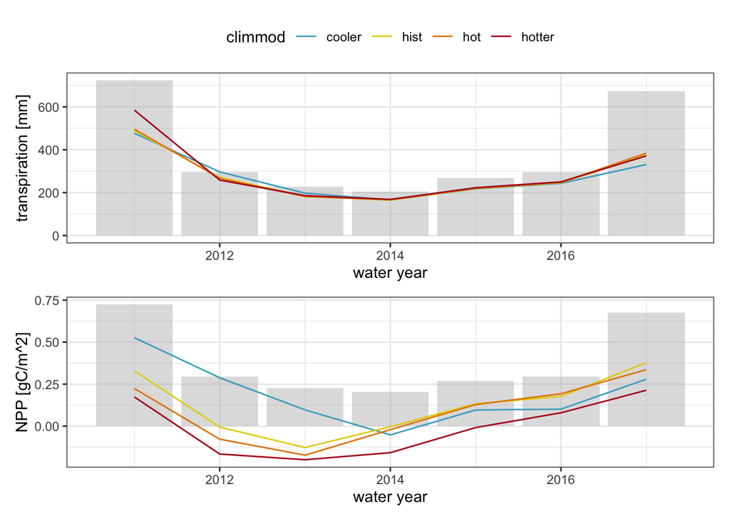

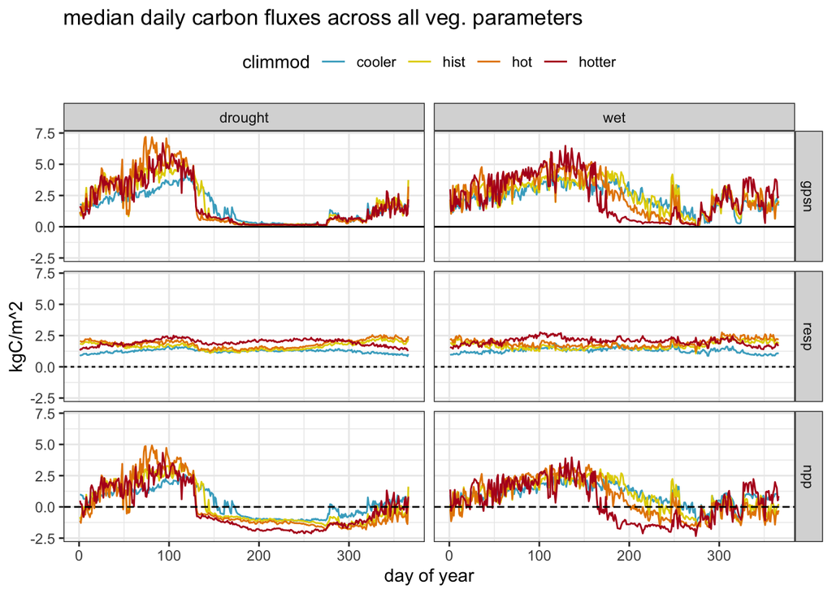

## Sensitivity Analysis results

should there be a threshold for the indices so that there’s not low values in the table? would it depend on first or total, or both?

Sobol sensitivity analysis

pre-drought LAI

|  | rank | Deciduous original_dec | Deciduous ci_dec | Evergreen original_evg | Evergreen ci_evg |
| --- | --- | --- | --- | --- | --- |
| leaf property |  |  |  |  |  |
| epc.proj_sla | T | NA | [NA,NA] | 0.09 | [NA,NA] |
| epc.proj_sla | S | NA | [NA,NA] | 0.19 | [NA,NA] |
| turnover rates |  |  |  |  |  |
| epc.leaf_turnover | T | 0.17 | [0.09,0.22] | 0.74 | [0.09,0.22] |
| epc.branch_turnover | T | NA | [NA,NA] | 0.02 | [NA,NA] |
| epc.leaf_turnover | S | 0.20 | [0,0.51] | 0.76 | [0,0.51] |
| epc.branch_turnover | S | NA | [NA,NA] | 0.08 | [NA,NA] |
| carbon allocation |  |  |  |  |  |
| epc.alloc_stemc_leafc | T | 0.39 | [0.17,0.5] | NA | [0.17,0.5] |
| epc.waring_pb | T | 0.30 | [0.15,0.39] | 0.02 | [0.15,0.39] |
| epc.waring_pa | T | 0.16 | [0.07,0.2] | 0.06 | [0.07,0.2] |
| epc.alloc_stemc_leafc | S | 0.24 | [0.02,0.58] | NA | [0.02,0.58] |
| epc.waring_pb | S | 0.18 | [-0.09,0.57] | 0.10 | [-0.09,0.57] |
| epc.waring_pa | S | 0.25 | [0.03,0.59] | 0.10 | [0.03,0.59] |
| soil |  |  |  |  |  |
| pore_size_index | T | 0.31 | [0.19,0.39] | NA | [0.19,0.39] |
| pore_size_index | S | 0.17 | [-0.1,0.58] | NA | [-0.1,0.58] |

Sobol sensitivity analysis

LAI Resilience

|  | rank | Deciduous original_dec | Deciduous ci_dec | Evergreen original_evg | Evergreen ci_evg |
| --- | --- | --- | --- | --- | --- |
| tree property |  |  |  |  |  |
| epc.root_distrib_parm | T | NA | [NA,NA] | 0.41 | [NA,NA] |
| epc.root_distrib_parm | S | NA | [NA,NA] | 0.14 | [NA,NA] |
| turnover rates |  |  |  |  |  |
| epc.froot_turnover | T | 0.67 | [0.28,0.86] | 0.26 | [0.28,0.86] |
| epc.branch_turnover | T | NA | [NA,NA] | 0.40 | [NA,NA] |
| epc.froot_turnover | S | −0.43 | [-0.8,0.36] | 0.13 | [-0.8,0.36] |
| epc.branch_turnover | S | NA | [NA,NA] | 0.21 | [NA,NA] |
| carbon allocation and photosynthesis |  |  |  |  |  |
| epc.storage_transfer_prop | T | 0.65 | [0.35,0.83] | NA | [0.35,0.83] |
| epc.waring_pb | T | 0.64 | [0.4,0.8] | NA | [0.4,0.8] |
| epc.netpabs_sunlit | T | 0.60 | [0.35,0.77] | 0.26 | [0.35,0.77] |
| epc.storage_transfer_prop | S | −0.22 | [-0.64,0.47] | NA | [-0.64,0.47] |
| epc.waring_pb | S | −0.31 | [-0.67,0.28] | NA | [-0.67,0.28] |
| epc.netpabs_sunlit | S | −0.26 | [-0.64,0.23] | 0.15 | [-0.64,0.23] |
| soil |  |  |  |  |  |
| pore_size_index | T | 0.72 | [0.42,0.88] | NA | [0.42,0.88] |
| psi_air_entry | T | NA | [NA,NA] | 0.43 | [NA,NA] |
| pore_size_index | S | −0.04 | [-0.34,0.41] | NA | [-0.34,0.41] |
| psi_air_entry | S | NA | [NA,NA] | 0.12 | [NA,NA] |

## Supplementary plots

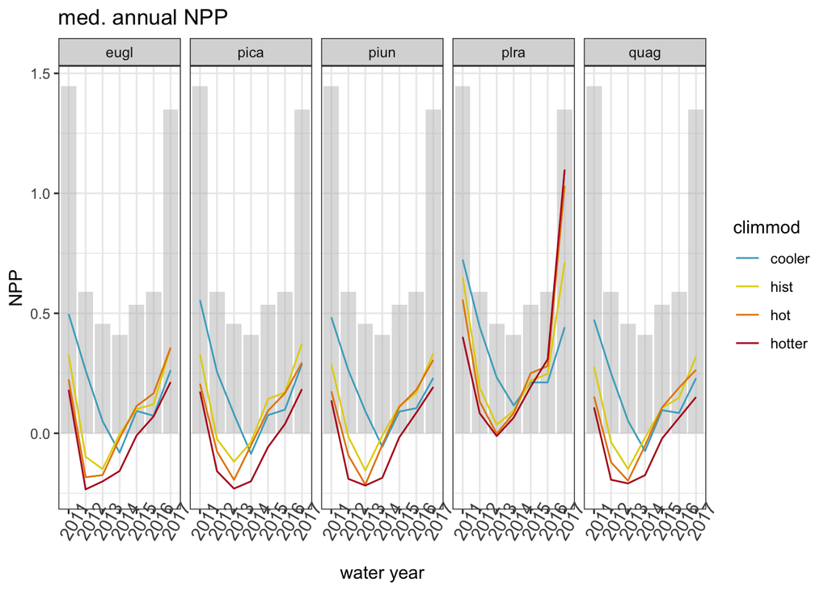

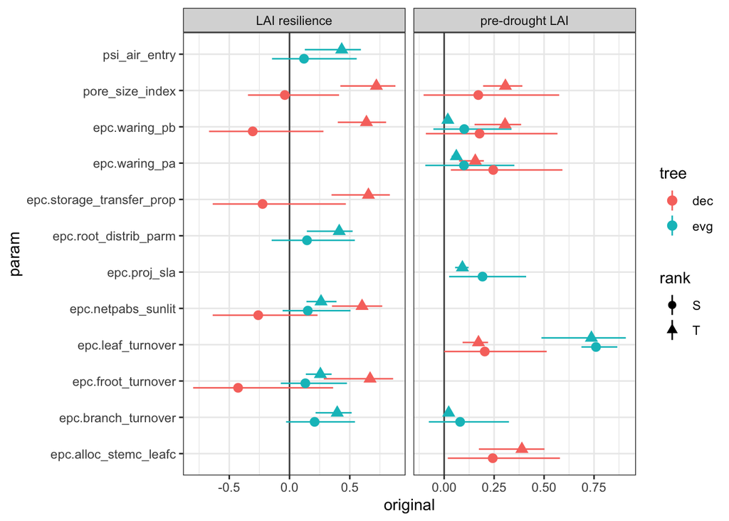

# Species differences in NPP shifts during drought years

calculate changes in peak npp to negative npp for each species and climate. use Day of center of mass - so 50% of it happens before and 50% after

- with taking center of mass of GPSN
- trying to do the same with NPP

```
## $int
## [1] 610.1578
##
## $half
## [1] 125
```

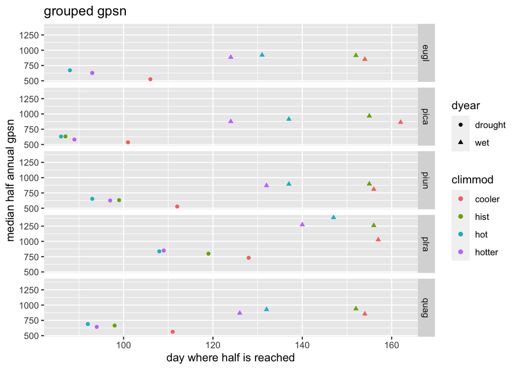

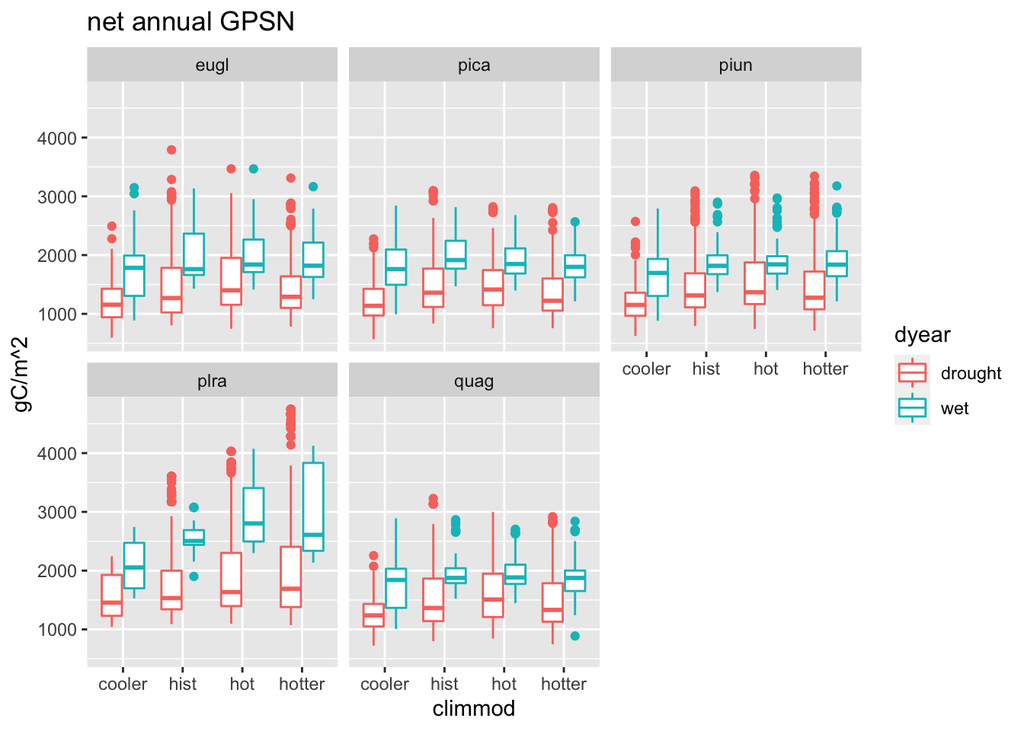

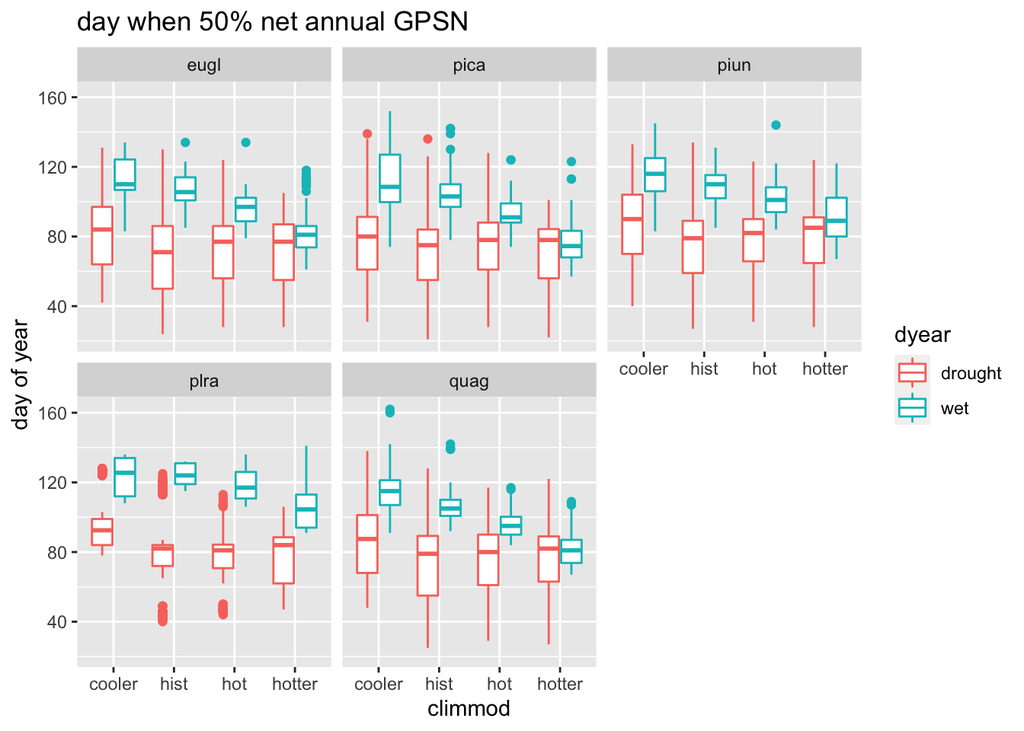

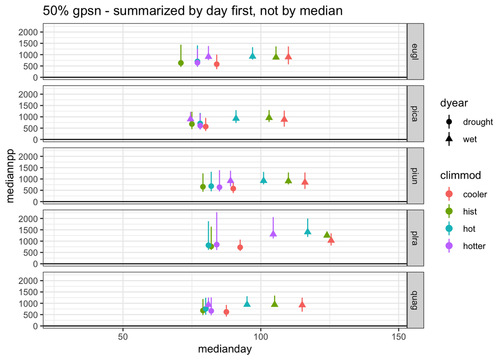

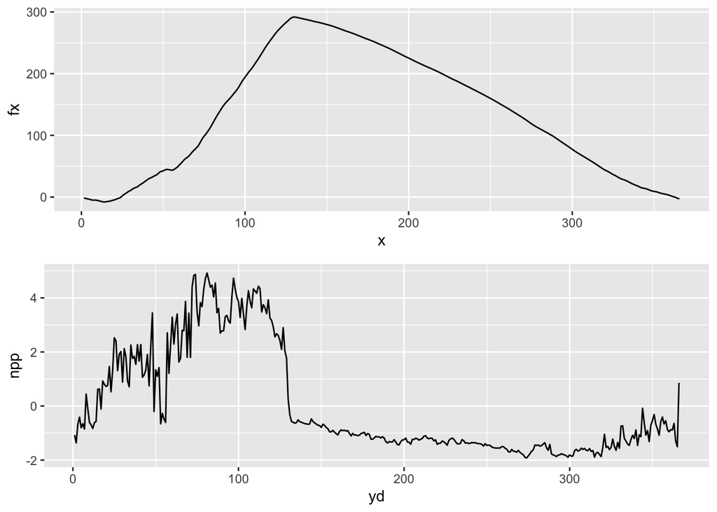

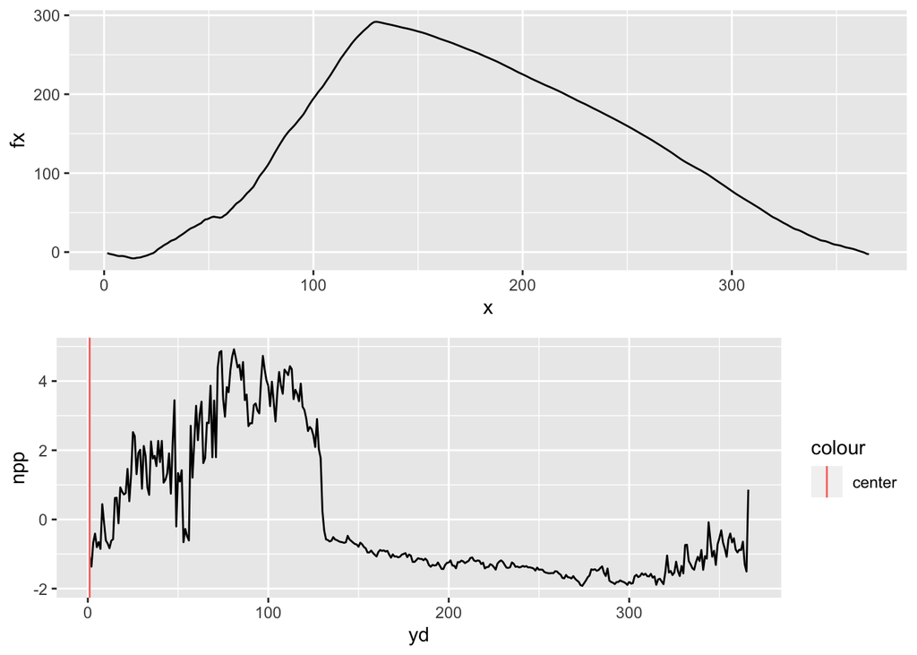

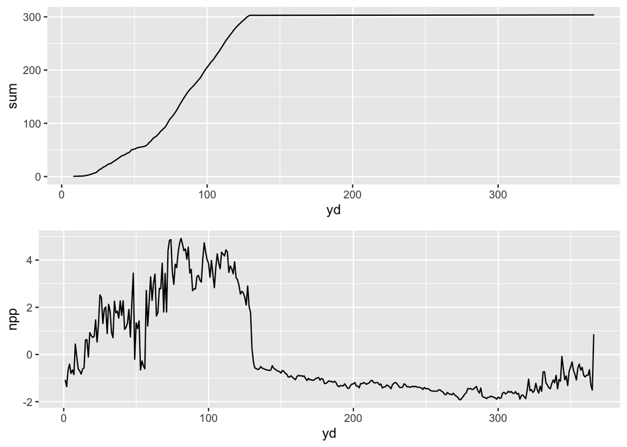

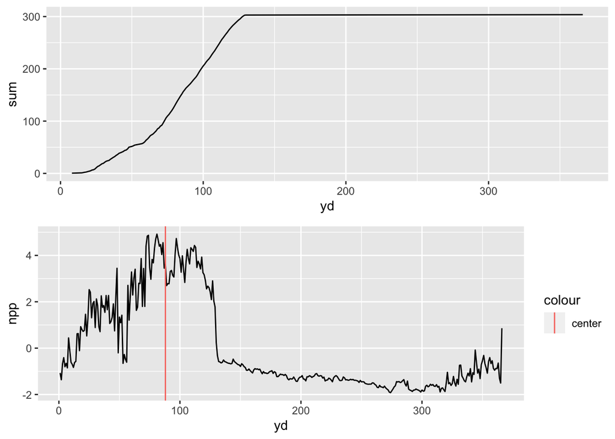